# Homework 6

```r
library("forecast")
```

For this assignment, we analyze the `chaos1` and `chaos2` series.

```r
chaos1 <- read.csv("http://ptrckprry.com/course/forecasting/data/chaos1.csv")$value
chaos2 <- read.csv("http://ptrckprry.com/course/forecasting/data/chaos2.csv")$value
time <- 1:50
```

## Problem 1

```r
x <- .500

f1 <- function(x) {
  x <- x/.6
  print(x)
}

f2 <- function(x) {
  x <- ((1-x)/.4)
  print(x)
}


for (i in 1:50) {
  if (0 <= x & x <= .6)
    x <- f1(x)
  else
    x <- f2(x)
  }
```

```
## [1] 0.8333333
## [1] 0.4166667
## [1] 0.6944444
## [1] 0.7638889
## [1] 0.5902778
## [1] 0.9837963
## [1] 0.04050926
## [1] 0.06751543
## [1] 0.1125257
## [1] 0.1875429
## [1] 0.3125714
## [1] 0.5209524
## [1] 0.868254
## [1] 0.329365
## [1] 0.5489416
```

[output cut: 35 more lines]

**Check that `x1 = f(x0)`, for `chaos1`.**

x1 matches f(x0). The results are off by a small margin of error. The last observation in chaos1 is 0.99152051 while my check has a final value of 0.98681. The values digress later in the dataset but we can infer that x1 = f(x0).

## Problem 2

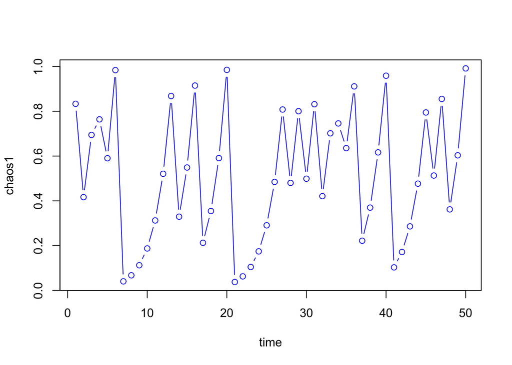

```r
# Plot chaos1 and chaos2 in separate plots.
par(mfrow=c(1,1))
plot(time, chaos1, type = 'b', col = 4)
```

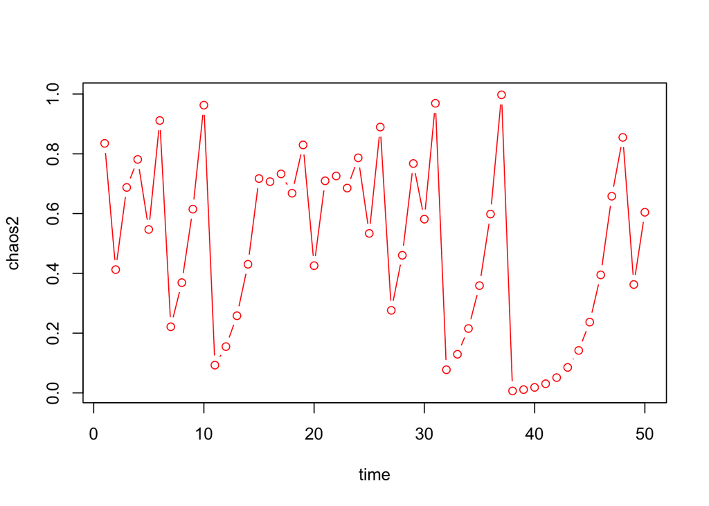

```r
par(mfrow=c(1,1))
plot(time, chaos2, type = 'b', col = 2)
```

**Do the series look random?**

Chaos2 appears to be more random versus Chaos1. The f2(x) output does not drop close zero at a consistant cadence like f1(x).

**Are they in fact random?**

No they are not random. Both plots have structure in them. In both plots, there are tendencies for both plots to trend upward overtime, until it reaches a shock and drops drastically. Because of this pattern and structure, I conclude that these models are not random.

**Do the series look stationary?**

The models do look stationary overtime.

## Problem 3

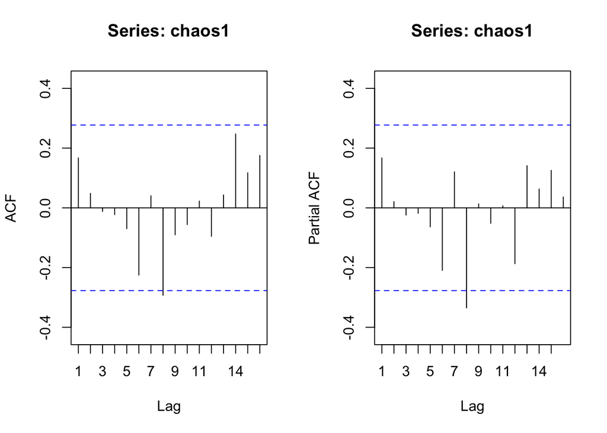

```r
par(mfrow=c(1,2))
Acf(chaos1)
Pacf(chaos1)
```

**Based on these, suggest an ARMA model.**

**Would this model provide the best possible forecasts?**

## Problem 4

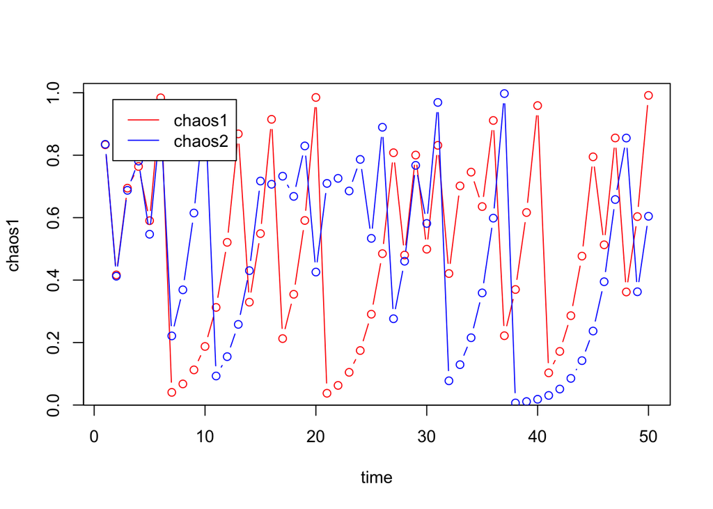

```r
par(mfrow=c(1,1))
plot(time, chaos1,
     type = 'b', col = 2)
lines(time, chaos2,
      type = 'b', col = 4)

legend("topleft", inset=0.05,
       legend=c("chaos1", "chaos2"), lty = c(1,1), col=c("red","blue"))
```

**Do the paths look similar?**

The plots look similar in terms of structure over time. The difference is the lag between shocks in both plots.

**Should they look similar when t is close to 1?**

Yes, they should look similar when t is close to 1 because they have very similar starting points in x{t} = .500 and x{t} = .501. The divergence begins after either function experiences its first shock and from there they become less similar.

**What should happen if `chaos1` and `chaos2` happen to get very close together at some later time?**

They follow the same patterns. They esentially look identificaly. Again, both functions are the same minus the starting point so when they meet, they follow the same y values until the next shock.

## Problem 5

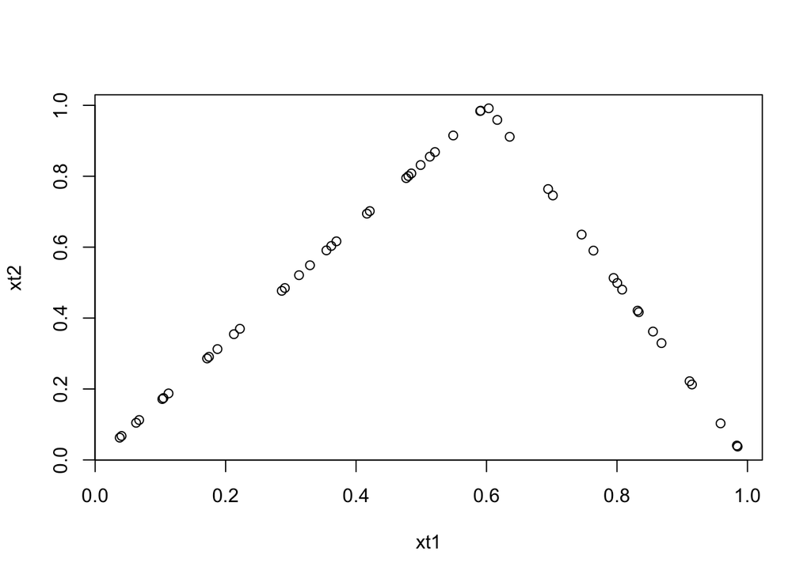

```r
xt1 <- chaos1[-50]
xt2 <- chaos1[-1]

plot(xt1, xt2, type = "p")
```

**Does this plot reveal the map (in other words, the function *f*) which generated the data?**

Yes this plot reveals the function.

**Do you see why this *f* is called the tent map?**

This is called the tent map because the shape of the plot is that of a tent.

**Does this plot help us to see that `{ x_t }` is not an AR(1) series? How?**

Yes because it shows that the series is not completely random. There is clear structure in how data is generated.